# Introduction to Machine Learning (Syllabus/Code for Day 2): Solutions for Learning in Supervised and Unsupervised Settings

```r
#install.packages("pacman")
library(pacman)
p_load(infotheo)
p_load(tidyverse)
p_load(ggplot2)
p_load(cowplot)
p_load(mlbench)
p_load(Metrics)
#remove.packages("rlang")
#install.packages("rlang", repos = "https://cloud.r-project.org")
set.seed(123)
```

# 1 Wisconsin Breast Cancer Dataset

BreastCancer Dataset  
A data frame with 699 observations on 11 variables, one being a character variable, 9 being ordered or nominal, and 1 target class.

1. Sample code number: id number
2. Clump Thickness: 1 - 10
3. Uniformity of Cell Size: 1 - 10
4. Uniformity of Cell Shape: 1 - 10
5. Marginal Adhesion: 1 - 10
6. Single Epithelial Cell Size: 1 - 10
7. Bare Nuclei: 1 - 10
8. Bland Chromatin: 1 - 10
9. Normal Nucleoli: 1 - 10
10. Mitoses: 1 - 10
11. Class: (benign, malignant)

Breast Cancer Wisconsin (Original) Data Set

[“Multisurface method of pattern separation for medical diagnosis applied to breast cytology.”](http://www.pnas.org/content/pnas/87/23/9193.full.pdf), Wolberg,W.H., Mangasarian,O.L. (1990). In Proceedings of the National Academy of Sciences, 87, 9193-9196.

Zhang,J. (1992). Selecting typical instances in instance-based learning. In Proceedings of the Ninth International Machine Learning Conference (pp. 470-479). Aberdeen, Scotland: Morgan Kaufmann.

## 1.1 Cleaning and documentation

```r
data(BreastCancer)
glimpse(BreastCancer)
```

```
Observations: 699
Variables: 11
$ Id              <chr> "1000025", "1002945", "1015425", "1016277", "1017023", "1017122", "1018099", "1018561", "1033078",...
$ Cl.thickness    <ord> 5, 5, 3, 6, 4, 8, 1, 2, 2, 4, 1, 2, 5, 1, 8, 7, 4, 4, 10, 6, 7, 10, 3, 8, 1, 5, 3, 5, 2, 1, 3, 2, ...
$ Cell.size       <ord> 1, 4, 1, 8, 1, 10, 1, 1, 1, 2, 1, 1, 3, 1, 7, 4, 1, 1, 7, 1, 3, 5, 1, 4, 1, 2, 2, 1, 1, 1, 1, 1, 7...
$ Cell.shape      <ord> 1, 4, 1, 8, 1, 10, 1, 2, 1, 1, 1, 1, 3, 1, 5, 6, 1, 1, 7, 1, 2, 5, 1, 5, 1, 3, 1, 1, 1, 3, 1, 1, 7...
$ Marg.adhesion   <ord> 1, 5, 1, 1, 3, 8, 1, 1, 1, 1, 1, 1, 3, 1, 10, 4, 1, 1, 6, 1, 10, 3, 1, 1, 1, 4, 1, 1, 1, 1, 1, 1, ...
$ Epith.c.size    <ord> 2, 7, 2, 3, 2, 7, 2, 2, 2, 2, 1, 2, 2, 2, 7, 6, 2, 2, 4, 2, 5, 6, 2, 2, 2, 2, 1, 2, 2, 2, 1, 2, 8,...
$ Bare.nuclei     <fct> 1, 10, 2, 4, 1, 10, 10, 1, 1, 1, 1, 1, 3, 3, 9, 1, 1, 1, 10, 1, 10, 7, 1, NA, 1, 7, 1, 1, 1, 1, 1,...
$ Bl.cromatin     <fct> 3, 3, 3, 3, 3, 9, 3, 3, 1, 2, 3, 2, 4, 3, 5, 4, 2, 3, 4, 3, 5, 7, 2, 7, 3, 3, 2, 2, 2, 1, 2, 3, 7,...
$ Normal.nucleoli <fct> 1, 2, 1, 7, 1, 7, 1, 1, 1, 1, 1, 1, 4, 1, 5, 3, 1, 1, 1, 1, 4, 10, 1, 3, 1, 6, 1, 1, 1, 1, 1, 1, 4...
$ Mitoses         <fct> 1, 1, 1, 1, 1, 1, 1, 1, 5, 1, 1, 1, 1, 1, 4, 1, 1, 1, 2, 1, 4, 1, 1, 1, 1, 1, 1, 1, 1, 1, 1, 1, 3,...
$ Class           <fct> benign, benign, benign, benign, benign, malignant, benign, benign, benign, benign, benign, benign,...
```

```r
summary(BreastCancer$Class)
```

```
   benign malignant
      458       241
```

```r
BreastCancer$y <- as.factor(as.numeric(BreastCancer$Class=="malignant"))
BreastCancer$Class <- NULL
BreastCancer$Id <- NULL
BreastCancer[,1:5] <- lapply(BreastCancer[,1:5] , as.numeric)
summary(BreastCancer)
```

```
  Cl.thickness      Cell.size        Cell.shape     Marg.adhesion     Epith.c.size     Bare.nuclei   Bl.cromatin
 Min.   : 1.000   Min.   : 1.000   Min.   : 1.000   Min.   : 1.000   Min.   : 1.000   1      :402   2      :166
 1st Qu.: 2.000   1st Qu.: 1.000   1st Qu.: 1.000   1st Qu.: 1.000   1st Qu.: 2.000   10     :132   3      :165
 Median : 4.000   Median : 1.000   Median : 1.000   Median : 1.000   Median : 2.000   2      : 30   1      :152
 Mean   : 4.418   Mean   : 3.134   Mean   : 3.207   Mean   : 2.807   Mean   : 3.216   5      : 30   7      : 73
 3rd Qu.: 6.000   3rd Qu.: 5.000   3rd Qu.: 5.000   3rd Qu.: 4.000   3rd Qu.: 4.000   3      : 28   4      : 40
 Max.   :10.000   Max.   :10.000   Max.   :10.000   Max.   :10.000   Max.   :10.000   (Other): 61   5      : 34
                                                                                      NA's   : 16   (Other): 69
 Normal.nucleoli    Mitoses    y
 1      :443     1      :579   0:458
 10     : 61     2      : 35   1:241
 3      : 44     3      : 33
 2      : 36     10     : 14
 8      : 24     4      : 12
 6      : 22     7      :  9
 (Other): 69     (Other): 17
```

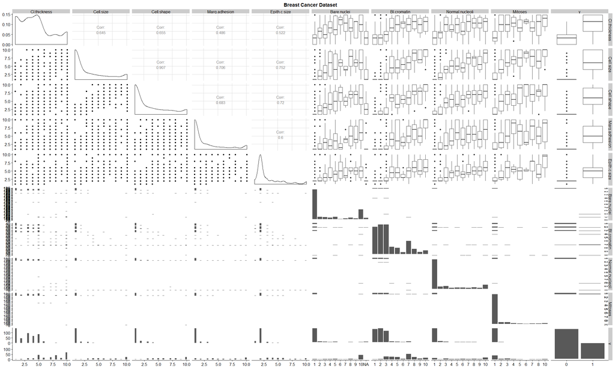

```r
p_load(GGally)
ggpairs(BreastCancer, title = "Breast Cancer Dataset")
```

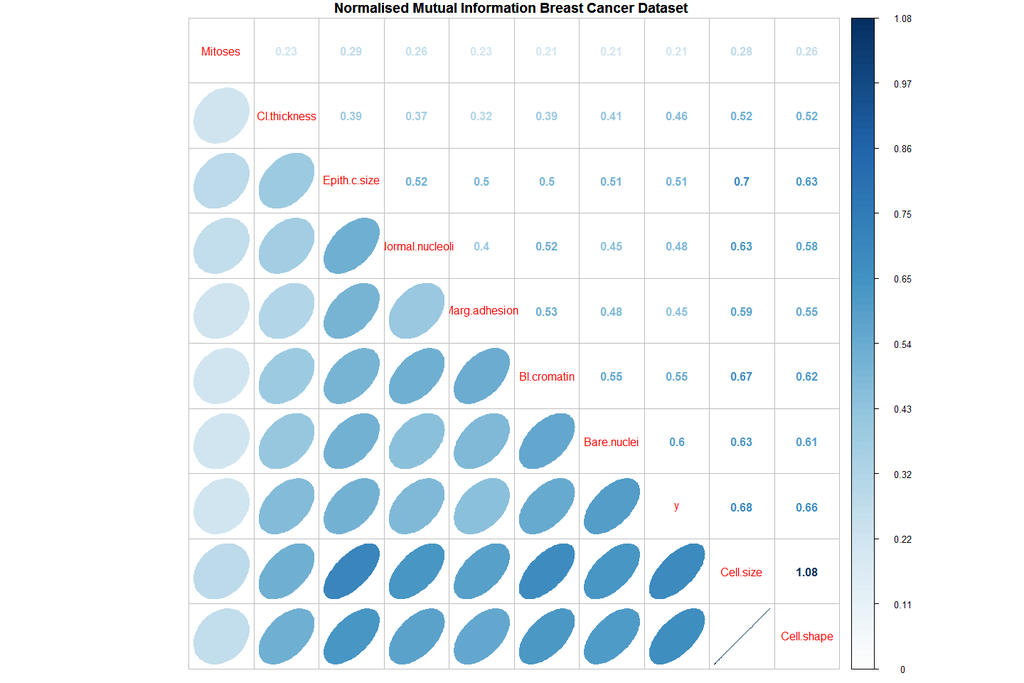

```r
p_load(corrplot)
p_load(infotheo)
BreastCancer_mi <- mutinformation(BreastCancer, method="emp") %>% natstobits()
#BreastCancer_mi <- BreastCancer_mi/max(BreastCancer_mi)
mi_max <- max( BreastCancer_mi[lower.tri(BreastCancer_mi, diag = FALSE)])
diag(BreastCancer_mi) <-0
corrplot.mixed(BreastCancer_mi,
               cl.lim = c(0,mi_max),
               title = "Normalised Mutual Information Breast Cancer Dataset",
               mar=c(0,0,1,0),
               lower = "ellipse",
               upper="number",
               is.corr = FALSE,
               order = "hclust"
)
```

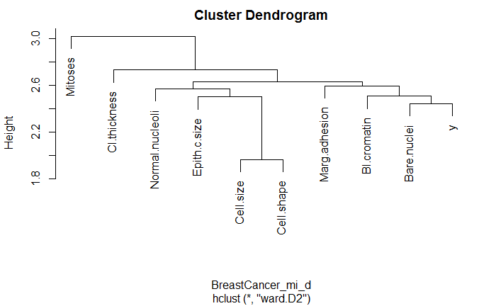

```r
p_load(infotheo)
BreastCancer_mi <- mutinformation(BreastCancer, method="emp") %>% natstobits()
BreastCancer_mi_d <- as.dist(max(BreastCancer_mi)-BreastCancer_mi)
hc <- hclust(BreastCancer_mi_d, method="ward.D2")
plot(hc)
```

There are 16 unexplained missing values on one of the features. We’re going to impute those values, being careful to not use the outcome as one of the predictors. This will allows us to make comparisons across methods that do not handle missing values well, and also will protect us on predicting onto new test data which might also have unexplained missingness.

[MissForest—non-parametric missing value imputation for mixed-type data](https://academic.oup.com/bioinformatics/article/28/1/112/219101), Daniel J. Stekhoven Peter Bühlmann, Bioinformatics, Volume 28, Issue 1, 1 January 2012, Pages 112–118,

```r
#There are 16 missing values in Bare.nuclei, they're continous
p_load("missForest")
BreastCancer_imputed <- BreastCancer
BreastCancer_imputed <- missForest(BreastCancer %>% select(-y), verbose = TRUE)$ximp
```

```
  missForest iteration 1 in progress...done!
    estimated error(s): 0 0.09553441
    difference(s): 0 0.001430615
    time: 1.23 seconds

  missForest iteration 2 in progress...done!
    estimated error(s): 0 0.08674963
    difference(s): 0 0.0003576538
    time: 1.19 seconds

  missForest iteration 3 in progress...done!
    estimated error(s): 0 0.09699854
    difference(s): 0 0.0007153076
    time: 1.02 seconds
```

```r
BreastCancer_imputed$y <- BreastCancer$y
```

Convert categorical variables to ‘one-hot’ dummy variables

[Making dummy variables with dummy_cols()](https://cran.r-project.org/web/packages/fastDummies/vignettes/making-dummy-variables.html), Jacob Kaplan, 2018-06-21

```r
#install.packages('data.table')
p_load(fastDummies)
BreastCancer_onehot <- fastDummies::dummy_cols(BreastCancer_imputed,
                                               select_columns=c("Bare.nuclei",
                                                                "Bl.cromatin",
                                                                "Normal.nucleoli",
                                                                "Mitoses"))
BreastCancer_onehot[,c('Bare.nuclei','Bl.cromatin','Normal.nucleoli','Mitoses')] <- NULL
```

# 2 Hold out a Test Set

The Very first thing we’re going to do is pull 20% of the Breat Cancer dataset out as a test set and we’re never going to touch it for any reason other than final model evaluation.

Immediately split off a test set that we will not touch until the very final evaluation.

```r
N=nrow(BreastCancer)
condition_train <- runif(N)<.8; table(condition_train)
```

```
condition_train
FALSE  TRUE
  127   572
```

```r
BreastCancer_train <- BreastCancer_imputed[condition_train,]
BreastCancer_test <- BreastCancer_imputed[!condition_train,]
BreastCancer_onehot_train <- BreastCancer_onehot[condition_train,]
BreastCancer_onehot_test <- BreastCancer_onehot[!condition_train,]
```

# 3 Supervised Learning

- IMLR [“Chapter 5 Supervised Learning”](https://lgatto.github.io/IntroMachineLearningWithR/supervised-learning.html)

```r
formula= y ~    Cl.thickness +
                           Cell.size +
                           Cell.shape +
                           Marg.adhesion +
                           Epith.c.size +
                           Bare.nuclei +
                           Bl.cromatin +
                           Normal.nucleoli +
                           Mitoses
#One Hot formula dummies
formula_onehot = y ~
Cl.thickness +
Cell.size +
Cell.shape +
Marg.adhesion +
Epith.c.size +
Bare.nuclei_1 + Bare.nuclei_10 + Bare.nuclei_2 + Bare.nuclei_4 + Bare.nuclei_3 + Bare.nuclei_9 + Bare.nuclei_7 +
Bare.nuclei_5 + Bare.nuclei_8 + Bare.nuclei_6 +  Bl.cromatin_3  +
Bl.cromatin_9 + Bl.cromatin_1+Bl.cromatin_2+Bl.cromatin_4+Bl.cromatin_5+Bl.cromatin_7  +
Bl.cromatin_8+Bl.cromatin_6+Bl.cromatin_10+

Normal.nucleoli_1 +  Normal.nucleoli_2 + Normal.nucleoli_7 +
Normal.nucleoli_4 + Normal.nucleoli_5 +  Normal.nucleoli_3 +
Normal.nucleoli_10 + Normal.nucleoli_6 +  Normal.nucleoli_9 +
Normal.nucleoli_8 +

Mitoses_1+ Mitoses_5 + Mitoses_4 + Mitoses_2+Mitoses_3 + Mitoses_7 + Mitoses_10 + Mitoses_8 + Mitoses_6
```

Register a single back end for cross-validation

```r
p_load(caret)
set.seed(123)
cctrl1 <- trainControl(method="cv",
                       number=10,
                       returnResamp="all",
                       classProbs=TRUE,
                       summaryFunction=twoClassSummary,
                       savePredictions=TRUE
                       )
```

# 4 Linear Models

- (ISLR) “Chapter 3 Linear Regression”
- [Ordinary_least_squares](https://en.wikipedia.org/wiki/)
- (ISLR) “Chapter 4.3 Logistic Regression”
- Logistic_regression
- [Glmnet Vignette](https://cran.r-project.org/web/packages/glmnet/vignettes/glmnet_beta.pdf)

```r
p_load(glmnet)
set.seed(123)
glm1 <- glm(formula_onehot ,
               data=BreastCancer_onehot_train ,
               family=binomial(link='probit')
            )
```

```
glm.fit: algorithm did not convergeglm.fit: fitted probabilities numerically 0 or 1 occurred
```

```r
library(broom)
tidy(glm1 ) #There are 44 features, counting dummified categorical variables
```

| term | estimate | std.error | statistic | p.value |
| --- | --- | --- | --- | --- |
| (Intercept) | 90015916010083.1250000000 | 123529743529485.7187500000 | 0.7286983154 | 0.46618622352 |
| Cl.thickness | 2.0077616486 | 0.8381329024 | 2.3955170390 | 0.01659694282 |
| Cell.size | -0.7207814917 | 0.3535178685 | -2.0388827722 | 0.04146172870 |
| Cell.shape | 2.3629694216 | 0.9470948292 | 2.4949660254 | 0.01259691907 |
| Marg.adhesion | 0.1424833846 | 0.1591305927 | 0.8953865009 | 0.37058051426 |
| Epith.c.size | 1.1619507190 | 0.5408507046 | 2.1483760844 | 0.03168389108 |
| Bare.nuclei_1 | 7456871027494.8310546875 | 46996405621039.3593750000 | 0.1586689648 | 0.87392969090 |
| Bare.nuclei_10 | 7456871027501.3320312500 | 47001734341082.0781250000 | 0.1586509760 | 0.87394386432 |
| Bare.nuclei_2 | 7456871027502.6572265625 | 47011340499032.9531250000 | 0.1586185577 | 0.87396940694 |
| Bare.nuclei_4 | 7456871027508.7167968750 | 47019559877225.6093750000 | 0.1585908300 | 0.87399125395 |

[output cut: 34 more lines]

Out of sample accuracy?

```
FALSE [1] 0.9368907
```

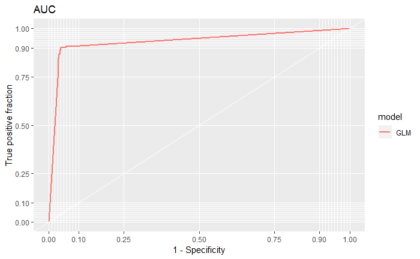

# 5 Variable Selection

- (ESL) “3 Linear Methods for Regression, 3.3 Subset Methods”
- Stepwise_regression

## 5.1 Feature Importance and P Values

- [A Machine Learning Alternative to P-values](https://arxiv.org/pdf/1701.04944.pdf),Min Lu and Hemant Ishwaran, February 22, 2017
- [ELI5](https://github.com/TeamHG-Memex/eli5)
- “Why Should I Trust You?”: Explaining the Predictions of Any Classifier, Marco Tulio Ribeiro, Sameer Singh, Carlos Guestrin, https://arxiv.org/abs/1602.04938 lime, Python Package, https://github.com/marcotcr/lime
- [Feature Selection with the R Package MXM: Statistically-Equivalent Feature Subsets](https://arxiv.org/pdf/1611.03227.pdf)
- [“bounceR”](https://github.com/STATWORX/bounceR), R Package
- [‘I JUST RAN Two MILLION REGRESSIONS’](http://www.ecostat.unical.it/Aiello/Didattica/economia_Crescita/CRESCITA/CRESCITA_Sala-i-Martin-AER-1997.pdf), Xavier Sala-i-Martin, 1997, American Economic Review
- Extreme_bounds_analysis
- [“ExtremeBounds: Extreme Bounds Analysis in R”](https://cran.r-project.org/web/packages/ExtremeBounds/vignettes/ExtremeBounds.pdf)

[Introduction to vimp](https://cran.r-project.org/web/packages/vimp/vignettes/introduction_to_vimp.html), Brian D. Williamson, 2018-06-19

## 5.2 Regularization, e.g. Lasso/Ridge Regression

- https://en.wikipedia.org/wiki/Lasso_(statistics)
- [“Regression shrinkage and selection via the lasso”](http://statweb.stanford.edu/~tibs/lasso/lasso.pdf), Tibshirani, R., 1996, J. Royal. Statist. Soc B., Vol. 58, No. 1, pages 267-288)
- [“Glmnet Vignette”](https://cran.r-project.org/web/packages/glmnet/vignettes/glmnet_beta.pdf), Trevor Hastie and Junyang Qian, September 13, 2016
- (ISLR) “6 Linear Model Selection and Regularization”
- (ESL) “3 Linear Methods for Regression, 3.4 Shrinkage Methods”

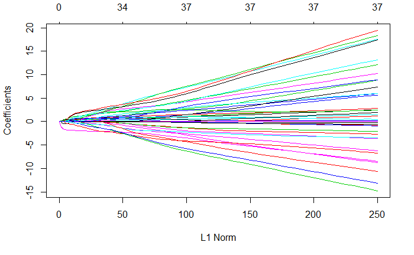

```r
set.seed(123)
glmnet1 <- glmnet(x=BreastCancer_onehot_train %>% select(-y) %>%  as.matrix(),
               y=as.factor(BreastCancer_onehot_train$y),
               family="binomial"
               )
plot(glmnet1)
```

```r
glmnet1_cv <- cv.glmnet(x=BreastCancer_onehot_train %>% select(-y) %>% data.matrix(),
                       y=as.factor(BreastCancer_onehot_train$y),
                       family="binomial",
                                nfolds=5)
glmnet1_cv$lambda.1se #smallest model with error within 1se error of the minimum ever observed
```

```
[1] 0.01817259
```

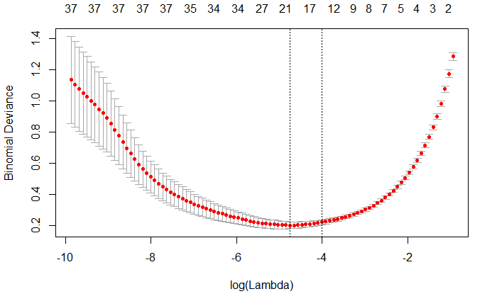

```r
plot(glmnet1_cv)
```

```r
glmnet_lambda.1se_betas <- coef(glmnet1_cv,s="lambda.1se") %>% as.matrix() %>% as.data.frame()  %>%
                           rename(beta='1') %>%
                           rownames_to_column() %>% arrange(desc(beta) )
#There are 44 features
#14 have been set to nonzero coefficients
#the cofficients are relatively small
#Design a single model around that optimal lambda
glmnet_lambda.1se <- glmnet(x=BreastCancer_onehot_train %>% select(-y) %>% data.matrix(),
                       y=BreastCancer_onehot_train$y,
                       family="binomial",
                       lambda=glmnet1_cv$lambda.1se
                       )
#cross validate that model to get estimate of accuracy on the test set
glmnet_lambda.1se_cv <- train(x=BreastCancer_onehot_train %>% select(-y) %>% data.matrix(),
                             y=as.factor(paste0('Outcome',BreastCancer_train$y)),
                             method = "glmnet",
                             trControl = cctrl1,
                             metric = "ROC",
                             tuneGrid = expand.grid(alpha = 1,lambda = glmnet1_cv$lambda.1se))
#Area Under the Curve Almost Perfect Now despite using only 14 of the 44 features
print(glmnet_lambda.1se_cv$results$ROC)  #0.99
```

```
[1] 0.9920091
```

```r
p_load(plotROC)
out_of_sample_predictions2 <- data.frame(y_hat=glmnet_lambda.1se_cv$pred$Outcome1,
                                               y=BreastCancer_train$y[glmnet_lambda.1se_cv$pred$rowIndex],
                                               model="Lasso")
basicplot <- ggplot(bind_rows(out_of_sample_predictions,
                              out_of_sample_predictions2),
                    aes(d = as.numeric(y), m = y_hat, color=model)) + geom_roc(n.cuts=0) +
                    style_roc(theme = theme_grey, xlab = "1 - Specificity") + ggtitle("AUC")
```

```
Unequal factor levels: coercing to characterbinding character and factor vector, coercing into character vectorbinding character and factor vector, coercing into character vector
```

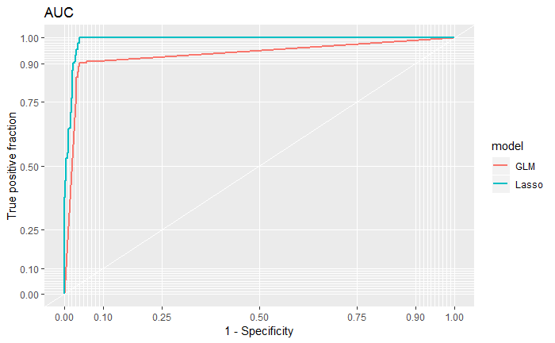

```r
basicplot
```

```r
NA
```

## 5.3 Linear Expansions and Interaction Terms

We can put the same feature in a linear multiple times with polynomials to capture nonlinear relationships.

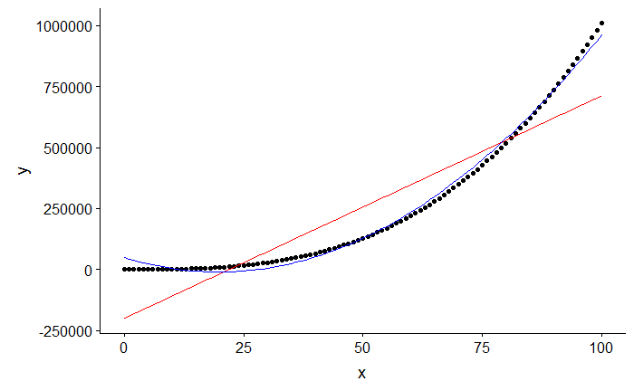

```r
set.seed(123)
library(dplyr)
df <- data.frame(x=seq(0,100)) %>%
  mutate(y=0+x+x^2+x^3)  %>%
  mutate(pred_lm      = lm(y~x    )$fitted.values) %>%
  mutate(pred_lm_quad = lm(y~x+I(x^2))$fitted.values)
library(ggplot2)
ggplot(df, aes(x,y))  +
         geom_point( aes(x,y)) +
         geom_line(aes(x=x,y=pred_lm), col='red')  +
         geom_line(aes(x=x,y=pred_lm_quad), col='blue')
```